# Assignment # 3

Qustion#1 Download the file

```r
fileUrl <- "https://d396qusza40orc.cloudfront.net/rprog%2Fdata%2FProgAssignment3-data.zip"

if (!file.exists("Assignment3-data.zip")) {
    download.file(fileUrl, destfile = "Assignment3-data.zip", method = "wget")
}
```

Unzip the file

```r
if (!file.exists("Assignment3-data")) {
    unzip("Assignment3-data.zip", overwrite = TRUE)
}
```

Get current working directory

```r
getwd()
```

```
## [1] "/Users/Vikas/share/rprog"
```

1- Plot the 30-day mortality rates for heart attack

read file

```r
outcome <- read.csv("outcome-of-care-measures.csv", colClasses = "character")
head(outcome)
```

```
##   Provider.Number                    Hospital.Name
## 1          010001 SOUTHEAST ALABAMA MEDICAL CENTER
## 2          010005    MARSHALL MEDICAL CENTER SOUTH
## 3          010006   ELIZA COFFEE MEMORIAL HOSPITAL
## 4          010007         MIZELL MEMORIAL HOSPITAL
## 5          010008      CRENSHAW COMMUNITY HOSPITAL
## 6          010010    MARSHALL MEDICAL CENTER NORTH
##                    Address.1 Address.2 Address.3         City State
## 1     1108 ROSS CLARK CIRCLE                           DOTHAN    AL
## 2 2505 U S HIGHWAY 431 NORTH                             BOAZ    AL
## 3         205 MARENGO STREET                         FLORENCE    AL
## 4              702 N MAIN ST                              OPP    AL
## 5        101 HOSPITAL CIRCLE                          LUVERNE    AL
## 6    8000 ALABAMA HIGHWAY 69                     GUNTERSVILLE    AL
##   ZIP.Code County.Name Phone.Number
```

[output cut: 258 more lines]

Number of columns

```r
ncol(outcome)
```

```
## [1] 46
```

Names of columns

```r
names(outcome)
```

```
##  [1] "Provider.Number"
##  [2] "Hospital.Name"
##  [3] "Address.1"
##  [4] "Address.2"
##  [5] "Address.3"
##  [6] "City"
##  [7] "State"
##  [8] "ZIP.Code"
##  [9] "County.Name"
## [10] "Phone.Number"
## [11] "Hospital.30.Day.Death..Mortality..Rates.from.Heart.Attack"
## [12] "Comparison.to.U.S..Rate...Hospital.30.Day.Death..Mortality..Rates.from.Heart.Attack"
## [13] "Lower.Mortality.Estimate...Hospital.30.Day.Death..Mortality..Rates.from.Heart.Attack"
## [14] "Upper.Mortality.Estimate...Hospital.30.Day.Death..Mortality..Rates.from.Heart.Attack"
## [15] "Number.of.Patients...Hospital.30.Day.Death..Mortality..Rates.from.Heart.Attack"
```

[output cut: 31 more lines]

Make a simple histogram of the 30-day death rates from heart attack (column 11 in the outcome dataset)

```r
names(outcome)[11]
```

```
## [1] "Hospital.30.Day.Death..Mortality..Rates.from.Heart.Attack"
```

```r
outcome[, 11] <- as.numeric(outcome[, 11])
## You may get a warning about NAs being introduced; that is okay
```

histogram

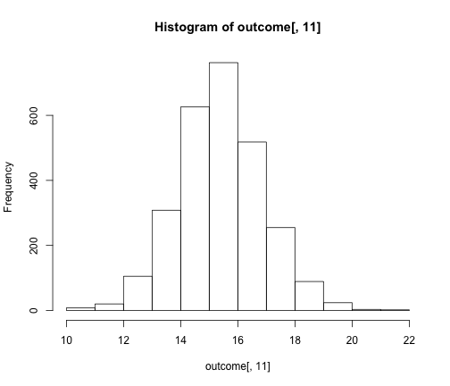

```r
hist(outcome[, 11])
```

# ##2 Finding the best hospital in a state

Write a function called best that take two arguments: the 2-character abbreviated name of a state and an outcome name. The function reads the outcome-of-care-measures.csv file and returns a character vector with the name of the hospital that has the best (i.e. lowest) 30-day mortality for the specified outcome in that state. The hospital name is the name provided in the Hospital.Name variable.

The outcomes can be one of “heart attack”, “heart failure”, or “pneumonia”.

Hospitals that do not have data on a particular outcome should be excluded from the set of hospitals when deciding the rankings.

```r
best <- function(state, outcome) {
    ## Read outcome data
    df <- read.csv("./outcome-of-care-measures.csv", colClasses = c(Hospital.30.Day.Death..Mortality..Rates.from.Heart.Attack = "character",
        Hospital.30.Day.Death..Mortality..Rates.from.Heart.Failure = "character",
        Hospital.30.Day.Death..Mortality..Rates.from.Pneumonia = "character",
        Hospital.Name = "character"))
    suppressWarnings(class(df$Hospital.30.Day.Death..Mortality..Rates.from.Heart.Attack) <- "numeric")
    suppressWarnings(class(df$Hospital.30.Day.Death..Mortality..Rates.from.Heart.Failure) <- "numeric")
    suppressWarnings(class(df$Hospital.30.Day.Death..Mortality..Rates.from.Pneumonia) <- "numeric")

    ## Check that state and outome are valid
    outcomes <- c("heart attack", "heart failure", "pneumonia")
    if (!(state %in% df$State)) {
        stop("invalid state")
    }

    if (!(outcome %in% outcomes)) {
        stop("invalid outcome")
    }

    ## Return hospital name in that state with lowest 30-day death rate
    df1 <- df[df$State == state, ]  # Subset of data for specific state.
    if (outcome == "heart attack") {
        return(min(df1[df1$Hospital.30.Day.Death..Mortality..Rates.from.Heart.Attack ==
            min(df1$Hospital.30.Day.Death..Mortality..Rates.from.Heart.Attack,
                na.rm = T), 2], na.rm = T))
    } else if (outcome == "heart failure") {
        return(min(df1[df1$Hospital.30.Day.Death..Mortality..Rates.from.Heart.Failure ==
            min(df1$Hospital.30.Day.Death..Mortality..Rates.from.Heart.Failure,
                na.rm = T), 2], na.rm = T))
    } else if (outcome == "pneumonia") {
        return(min(df1[df1$Hospital.30.Day.Death..Mortality..Rates.from.Pneumonia ==
            min(df1$Hospital.30.Day.Death..Mortality..Rates.from.Pneumonia,
                na.rm = T), 2], na.rm = T))
    }
}
```

Unit tests

```r
rm(list = ls())
best("TX", "heart attack")
```

```
## Error: could not find function "best"
```

```r
best("TX", "heart failure")
```

```
## Error: could not find function "best"
```

```r
best("MD", "heart attack")
```

```
## Error: could not find function "best"
```

```r
best("MD", "pneumonia")
```

```
## Error: could not find function "best"
```

```r
best("BB", "heart attack")
```

```
## Error: could not find function "best"
```

```r
best("NY", "hert attack")
```

```
## Error: could not find function "best"
```

```r
best("SC", "heart attack")
```

```
## Error: could not find function "best"
```

```r
best("NY", "pneumonia")  # [1] 'ALBANY MEDICAL CENTER HOSPITAL'  ## Incorrect results
```

```
## Error: could not find function "best"
```

```r
best("NN", "pneumonia")
```

```
## Error: could not find function "best"
```

Submission

```r
source("http://d396qusza40orc.cloudfront.net/rprog%2Fscripts%2Fsubmitscript3.R")
submit()
```

```
## Submission login (email):
## Submission  password:
## [1] 'best' part 1
## [2] 'best' part 2
## [3] 'best' part 3
## [4] 'rankhospital' part 1
## [5] 'rankhospital' part 2
## [6] 'rankhospital' part 3
## [7] 'rankhospital' part 4
## [8] 'rankall' part 1
## [9] 'rankall' part 2
## [10] 'rankall' part 3
## Which part are you submitting [1-10]?
```

```
## Error: missing value where TRUE/FALSE needed
```

```r
`?`(read.csv)
```

```r
df <- read.csv("./outcome-of-care-measures.csv", colClasses = c(Hospital.30.Day.Death..Mortality..Rates.from.Heart.Attack = "character",
    Hospital.30.Day.Death..Mortality..Rates.from.Heart.Failure = "character",
    Hospital.30.Day.Death..Mortality..Rates.from.Pneumonia = "character", Hospital.Name = "character"))
head(df$State)
```

```
## [1] AL AL AL AL AL AL
## 54 Levels: AK AL AR AZ CA CO CT DC DE FL GA GU HI IA ID IL IN KS KY ... WY
```

```r
class(df$Hospital.30.Day.Death..Mortality..Rates.from.Heart.Attack[1:10])
```

```
## [1] "character"
```

```r
class(df$State)
```

```
## [1] "factor"
```

```r
"BB" %in% df$State  ## To Check if State is valid.
```

```
## [1] FALSE
```

```r
"AL" %in% df$State
```

```
## [1] TRUE
```

```r
head(df$Hospital.Name)
```

```
## [1] "SOUTHEAST ALABAMA MEDICAL CENTER" "MARSHALL MEDICAL CENTER SOUTH"
## [3] "ELIZA COFFEE MEMORIAL HOSPITAL"   "MIZELL MEMORIAL HOSPITAL"
## [5] "CRENSHAW COMMUNITY HOSPITAL"      "MARSHALL MEDICAL CENTER NORTH"
```

```r
outcomes <- c("heart attack", "heart failure", "pneumonia")
"heart attack" %in% outcomes
```

```
## [1] TRUE
```

```r
"hert attack" %in% outcomes
```

```
## [1] FALSE
```

```r
if (!("BB" %in% df$State)) {
    stop("invalid state")
}
```

```
## Error: invalid state
```

```r
if (!("hert attack" %in% outcomes)) {
    stop("invalid outcome")
}
```

```
## Error: invalid outcome
```

```r
df$Hospital.30.Day.Death..Mortality..Rates.from.Heart.Attack
```

[output not shown]

[output cut: 1162 more lines]

```r
str(df$Hospital.30.Day.Death..Mortality..Rates.from.Heart.Attack)
```

```
##  chr [1:4706] "14.3" "18.5" "18.1" "Not Available" ...
```

Find NA values

```r
df$Hospital.30.Day.Death..Mortality..Rates.from.Heart.Attack == "Not Available"
```

[output not shown]

[output cut: 413 more lines]

```r
df$Hospital.30.Day.Death..Mortality..Rates.from.Heart.Attack[1:10]
```

```
##  [1] "14.3"          "18.5"          "18.1"          "Not Available"
##  [5] "Not Available" "Not Available" "17.7"          "18.0"
##  [9] "15.9"          "Not Available"
```

```r
# as.numeric(df$Hospital.30.Day.Death..Mortality..Rates.from.Heart.Attack)[1:10]
# as.character(df$Hospital.30.Day.Death..Mortality..Rates.from.Heart.Attack)[1:10]
as.numeric(df$Hospital.30.Day.Death..Mortality..Rates.from.Heart.Attack)[1:10]
```

```
##  [1] 14.3 18.5 18.1   NA   NA   NA 17.7 18.0 15.9   NA
```

Max and Min [refer-1](http://stat.ethz.ch/R-manual/R-devel/library/base/html/Extremes.html)

```r
max(as.numeric(df$Hospital.30.Day.Death..Mortality..Rates.from.Heart.Attack))
```

```
## [1] NA
```

```r
min(as.numeric(df$Hospital.30.Day.Death..Mortality..Rates.from.Heart.Attack))
```

```
## [1] NA
```

```r
max(as.numeric(df$Hospital.30.Day.Death..Mortality..Rates.from.Heart.Attack),
    na.rm = T)
```

```
## [1] 21.9
```

```r
min(as.numeric(df$Hospital.30.Day.Death..Mortality..Rates.from.Heart.Attack),
    na.rm = T)
```

```
## [1] 10.1
```

```r
max(df$Hospital.30.Day.Death..Mortality..Rates.from.Heart.Attack, na.rm = T)
```

```
## [1] "Not Available"
```

```r
min(df$Hospital.30.Day.Death..Mortality..Rates.from.Heart.Attack, na.rm = T)
```

```
## [1] "10.1"
```

```r
df$Hospital.30.Day.Death..Mortality..Rates.from.Heart.Attack == min(df$Hospital.30.Day.Death..Mortality..Rates.from.Heart.Attack,
    na.rm = T)
```

[output not shown]

[output cut: 413 more lines]

```r
any(df$Hospital.30.Day.Death..Mortality..Rates.from.Heart.Attack == min(df$Hospital.30.Day.Death..Mortality..Rates.from.Heart.Attack,
    na.rm = T))
```

```
## [1] TRUE
```

```r
sum(df$Hospital.30.Day.Death..Mortality..Rates.from.Heart.Attack == min(df$Hospital.30.Day.Death..Mortality..Rates.from.Heart.Attack,
    na.rm = T))
```

```
## [1] 1
```

Number of matches found

```r
sum(df$Hospital.30.Day.Death..Mortality..Rates.from.Heart.Attack == min(df$Hospital.30.Day.Death..Mortality..Rates.from.Heart.Attack,
    na.rm = T))
```

```
## [1] 1
```

```r
df[df$Hospital.30.Day.Death..Mortality..Rates.from.Heart.Attack == min(df$Hospital.30.Day.Death..Mortality..Rates.from.Heart.Attack,
    na.rm = T), 2]
```

```
## [1] "NYU HOSPITALS CENTER"
```

Find the details for Texas

```r
df1 <- df[df$State == "TX", ]
```

```r
df1[df1$Hospital.30.Day.Death..Mortality..Rates.from.Heart.Attack == min(df1$Hospital.30.Day.Death..Mortality..Rates.from.Heart.Attack,
    na.rm = T), 2]
```

```
## [1] "CYPRESS FAIRBANKS MEDICAL CENTER"
```

Resolve Conflict by choosing the first hospital in alphabetical order

```r
min(df1[df1$Hospital.30.Day.Death..Mortality..Rates.from.Heart.Attack == min(df1$Hospital.30.Day.Death..Mortality..Rates.from.Heart.Attack,
    na.rm = T), 2])
```

```
## [1] "CYPRESS FAIRBANKS MEDICAL CENTER"
```

Find the details for MD

```r
df1 <- df[df$State == "MD", ]
```

```r
df1[df1$Hospital.30.Day.Death..Mortality..Rates.from.Pneumonia == min(df1$Hospital.30.Day.Death..Mortality..Rates.from.Pneumonia,
    na.rm = T), 2]
```

```
## [1] "CALVERT MEMORIAL HOSPITAL"      "HOWARD COUNTY GENERAL HOSPITAL"
```

Find the details for NY

```r
df1 <- df[df$State == "NY", ]
```

```r
df1[df1$Hospital.30.Day.Death..Mortality..Rates.from.Pneumonia == min(df1$Hospital.30.Day.Death..Mortality..Rates.from.Pneumonia,
    na.rm = T), 2]
```

```
## [1] "ALBANY MEDICAL CENTER HOSPITAL"
## [2] "JOHN T MATHER MEMORIAL HOSPITAL  OF PORT JEFFERSON"
## [3] "LUTHERAN MEDICAL CENTER"
```

```r
min(df1[df1$Hospital.30.Day.Death..Mortality..Rates.from.Pneumonia == min(df1$Hospital.30.Day.Death..Mortality..Rates.from.Pneumonia,
    na.rm = T), 2])
```

```
## [1] "ALBANY MEDICAL CENTER HOSPITAL"
```

```r
min(df1$Hospital.30.Day.Death..Mortality..Rates.from.Pneumonia)
```

```
## [1] "10.0"
```

```r
sum(df1$Hospital.30.Day.Death..Mortality..Rates.from.Pneumonia == 10)
```

```
## [1] 0
```

```r
sum(df1$Hospital.30.Day.Death..Mortality..Rates.from.Pneumonia == "10.0")
```

```
## [1] 3
```

# Question#3

##Ranking hospitals by outcome in a state

```r
rm(list = ls())
```

```r
rankhospital <- function(state, outcome, num) {
    # Read the file outcome-of-care-measures.csv
    df <- read.csv("./outcome-of-care-measures.csv", colClasses = c(Hospital.30.Day.Death..Mortality..Rates.from.Heart.Attack = "character",
        Hospital.30.Day.Death..Mortality..Rates.from.Heart.Failure = "character",
        Hospital.30.Day.Death..Mortality..Rates.from.Pneumonia = "character",
        Hospital.Name = "character"))

    df[, 11] <- suppressWarnings(as.numeric(df[, 11]))
    df[, 17] <- suppressWarnings(as.numeric(df[, 17]))
    df[, 23] <- suppressWarnings(as.numeric(df[, 23]))

    outcomes <- c("heart attack", "heart failure", "pneumonia")

    if (!(state %in% df$State)) {
        stop("invalid state")
    }

    if (!(outcome %in% outcomes)) {
        stop("invalid outcome")
    }


    if (outcome == "heart attack") {
        df1 <- df[df$State == state, c(2, 11)]
        names(df1)[2] <- "Rate"
    }

    if (outcome == "heart failure") {
        df1 <- df[df$State == state, c(2, 17)]
        names(df1)[2] <- "Rate"
    }


    if (outcome == "pneumonia") {
        df1 <- df[df$State == state, c(2, 23)]
        names(df1)[2] <- "Rate"
    }
    # Remove rows where Ratings are not known.
    df1 <- df1[!is.na(df1$Rate), ]
    # Order the dataframe by Names to help in Ranking
    df1 <- df1[order(df1[1]), ]
    # head(df1) tail(df1)

    # Set Rank
    df1$rank <- rank(df1$Rate, ties.method = "first")

    # Return the values based on data provided
    if (num == "best") {
        return(df1[df1$rank == min(df1$rank), 1])
    } else if (num == "worst") {
        return(df1[df1$rank == max(df1$rank), 1])
    } else if ((num <= max(df1$rank)) | (num >= min(df1$rank))) {
        return(df1[df1$rank == num, 1])
    } else if ((num > max(df1$rank)) | (num < min(df1$rank))) {
        NA
    }
}
```

Unit tests

```r
rm(list = ls())
rankhospital("TX", "heart failure", 4)
```

```
## Error: could not find function "rankhospital"
```

```r
rankhospital("MD", "heart attack", "worst")
```

```
## Error: could not find function "rankhospital"
```

```r
rankhospital("MD", "heart attack", "best")
```

```
## Error: could not find function "rankhospital"
```

```r
rankhospital("MN", "heart attack", 5000)
```

```
## Error: could not find function "rankhospital"
```

```r
rankhospital("WA", "pneumonia", 1000)
```

```
## Error: could not find function "rankhospital"
```

Submission

```r
rm(list = ls())
source("http://d396qusza40orc.cloudfront.net/rprog%2Fscripts%2Fsubmitscript3.R")
submit()
```

```
## [1] 'best' part 1
## [2] 'best' part 2
## [3] 'best' part 3
## [4] 'rankhospital' part 1
## [5] 'rankhospital' part 2
## [6] 'rankhospital' part 3
## [7] 'rankhospital' part 4
## [8] 'rankall' part 1
## [9] 'rankall' part 2
## [10] 'rankall' part 3
## Which part are you submitting [1-10]?
```

```
## Error: missing value where TRUE/FALSE needed
```

```r
returnNA <- function() {
    return(NA)
}

returnNA()
```

```
## [1] NA
```

```r
`?`(return)
```

The function reads the outcome-of-care-measures.csv file

```r
df <- read.csv("./outcome-of-care-measures.csv", colClasses = c(Hospital.30.Day.Death..Mortality..Rates.from.Heart.Attack = "character",
    Hospital.30.Day.Death..Mortality..Rates.from.Heart.Failure = "character",
    Hospital.30.Day.Death..Mortality..Rates.from.Pneumonia = "character", Hospital.Name = "character"))

df$Hospital.30.Day.Death..Mortality..Rates.from.Heart.Attack <- as.numeric(df$Hospital.30.Day.Death..Mortality..Rates.from.Heart.Attack)
df$Hospital.30.Day.Death..Mortality..Rates.from.Heart.Failure <- as.numeric(df$Hospital.30.Day.Death..Mortality..Rates.from.Heart.Failure)
df$Hospital.30.Day.Death..Mortality..Rates.from.Pneumonia <- as.numeric(df$Hospital.30.Day.Death..Mortality..Rates.from.Pneumonia)
class(df$Hospital.30.Day.Death..Mortality..Rates.from.Heart.Attack)
```

```
## [1] "numeric"
```

```r
class(df$Hospital.30.Day.Death..Mortality..Rates.from.Heart.Failure)
```

```
## [1] "numeric"
```

```r
class(df$Hospital.30.Day.Death..Mortality..Rates.from.Pneumonia)
```

```
## [1] "numeric"
```

```r
state <- "NY"
outcome <- "heart attack"
outcome <- "heart failure"
outcome <- "penumonia"
outcomes <- c("heart attack", "heart failure", "pneumonia")
```

refer [link1](http://stackoverflow.com/a/1296745/2356016)

```r
if (outcome == "heart attack") {
    df1 <- df[df$State == state, c(2, 11)]
    names(df1)[2] <- "Rate"
}

if (outcome == "heart failure") {
    df1 <- df[df$State == state, c(2, 17)]
    names(df1)[2] <- "Rate"
}


if (outcome == "pneumonia") {
    df1 <- df[df$State == state, c(2, 23)]
    names(df1)[2] <- "Rate"
}
# Remove rows where Ratings are not known.
df1 <- df1[!is.na(df1$Rate), ]
```

```
## Error: object 'df1' not found
```

```r
# Order the dataframe by Names to help in Ranking
df1 <- df1[order(df1[1]), ]
```

```
## Error: object 'df1' not found
```

```r
head(df1)
```

```
## Error: object 'df1' not found
```

```r
tail(df1)
```

```
## Error: object 'df1' not found
```

```r
`?`(rank)
```

```r
`?`(order)
```

```r
class(df)
```

```
## [1] "data.frame"
```

Assign rank to dataframe

```r
df1$rank <- rank(df1$Rate, ties.method = "first")
```

```
## Error: object 'df1' not found
```

Test the results by viewing the results by sorting by ranks

```r
df1[order(df1[3]), ]
```

```
## Error: object 'df1' not found
```

```r
head(df1[order(df1[3]), ], 20)
```

```
## Error: object 'df1' not found
```

```r
tail(df1[order(df1[3]), ], 20)
```

```
## Error: object 'df1' not found
```

Find min max and num specific ranking rows

```r
df1[df1$rank == max(df1$rank), 1]
```

```
## Error: object 'df1' not found
```

```r
df1[df1$rank == min(df1$rank), 1]
```

```
## Error: object 'df1' not found
```

```r
df1[df1$rank == 1, 1]
```

```
## Error: object 'df1' not found
```

```r
df1[df1$rank == 1, 1]
```

```
## Error: object 'df1' not found
```

```r
df1[df1$rank == 171, 1]
```

```
## Error: object 'df1' not found
```

Return the results

```r
if (num == "best") {
    return(df1[df1$rank == min(df1$rank), 1])
} else if (num == "worst") {
    return(df1[df1$rank == max(df1$rank), 1])
} else if ((num <= max(df1$rank)) | (num >= min(df1$rank))) {
    return(df1[df1$rank == num, 1])
} else {
    return(NA)
}
```

```
## Error: object 'num' not found
```

```r
num <- "best"

if (num == "best") {
    return(df1[df1$rank == min(df1$rank), 1])
}
```

```
## Error: object 'df1' not found
```

Remove results with NA ratings

```r
df1[!is.na(df1$Rate), ]
```

```
## Error: object 'df1' not found
```

```r
str(df)
```

```
## 'data.frame':    4706 obs. of  46 variables:
##  $ Provider.Number                                                                      : Factor w/ 4706 levels "010001","010005",..: 1 2 3 4 5 6 7 8 9 10 ...
##  $ Hospital.Name                                                                        : chr  "SOUTHEAST ALABAMA MEDICAL CENTER" "MARSHALL MEDICAL CENTER SOUTH" "ELIZA COFFEE MEMORIAL HOSPITAL" "MIZELL MEMORIAL HOSPITAL" ...
##  $ Address.1                                                                            : Factor w/ 4681 levels " 1200 EAST PECAN ST",..: 454 2054 1690 3830 227 4081 3145 1551 128 1319 ...
##  $ Address.2                                                                            : logi  NA NA NA NA NA NA ...
##  $ Address.3                                                                            : logi  NA NA NA NA NA NA ...
##  $ City                                                                                 : Factor w/ 2926 levels "ABBEVILLE","ABERDEEN",..: 698 269 870 1910 1511 1064 241 900 19 241 ...
##  $ State                                                                                : Factor w/ 54 levels "AK","AL","AR",..: 2 2 2 2 2 2 2 2 2 2 ...
##  $ ZIP.Code                                                                             : int  36301 35957 35631 36467 36049 35976 35235 35968 35007 35233 ...
##  $ County.Name                                                                          : Factor w/ 1498 levels "ABBEVILLE","ACADIA",..: 642 844 770 340 349 844 684 381 1240 684 ...
##  $ Phone.Number                                                                         : num  3.35e+09 2.57e+09 2.57e+09 3.34e+09 3.34e+09 ...
##  $ Hospital.30.Day.Death..Mortality..Rates.from.Heart.Attack                            : num  14.3 18.5 18.1 NA NA NA 17.7 18 15.9 NA ...
##  $ Comparison.to.U.S..Rate...Hospital.30.Day.Death..Mortality..Rates.from.Heart.Attack  : Factor w/ 5 levels "Better than U.S. National Rate",..: 2 2 2 4 4 4 2 2 2 3 ...
##  $ Lower.Mortality.Estimate...Hospital.30.Day.Death..Mortality..Rates.from.Heart.Attack : Factor w/ 83 levels "10.0","10.1",..: 22 48 49 83 83 83 43 42 27 83 ...
##  $ Upper.Mortality.Estimate...Hospital.30.Day.Death..Mortality..Rates.from.Heart.Attack : Factor w/ 121 levels "12.4","12.5",..: 38 98 86 121 121 121 89 96 68 121 ...
```

[output cut: 32 more lines]

```r
names(df)
```

```
##  [1] "Provider.Number"
##  [2] "Hospital.Name"
##  [3] "Address.1"
##  [4] "Address.2"
##  [5] "Address.3"
##  [6] "City"
##  [7] "State"
##  [8] "ZIP.Code"
##  [9] "County.Name"
## [10] "Phone.Number"
## [11] "Hospital.30.Day.Death..Mortality..Rates.from.Heart.Attack"
## [12] "Comparison.to.U.S..Rate...Hospital.30.Day.Death..Mortality..Rates.from.Heart.Attack"
## [13] "Lower.Mortality.Estimate...Hospital.30.Day.Death..Mortality..Rates.from.Heart.Attack"
## [14] "Upper.Mortality.Estimate...Hospital.30.Day.Death..Mortality..Rates.from.Heart.Attack"
## [15] "Number.of.Patients...Hospital.30.Day.Death..Mortality..Rates.from.Heart.Attack"
```

[output cut: 31 more lines]

```r
head(df)
```

```
##   Provider.Number                    Hospital.Name
## 1          010001 SOUTHEAST ALABAMA MEDICAL CENTER
## 2          010005    MARSHALL MEDICAL CENTER SOUTH
## 3          010006   ELIZA COFFEE MEMORIAL HOSPITAL
## 4          010007         MIZELL MEMORIAL HOSPITAL
## 5          010008      CRENSHAW COMMUNITY HOSPITAL
## 6          010010    MARSHALL MEDICAL CENTER NORTH
##                    Address.1 Address.2 Address.3         City State
## 1     1108 ROSS CLARK CIRCLE        NA        NA       DOTHAN    AL
## 2 2505 U S HIGHWAY 431 NORTH        NA        NA         BOAZ    AL
## 3         205 MARENGO STREET        NA        NA     FLORENCE    AL
## 4              702 N MAIN ST        NA        NA          OPP    AL
## 5        101 HOSPITAL CIRCLE        NA        NA      LUVERNE    AL
## 6    8000 ALABAMA HIGHWAY 69        NA        NA GUNTERSVILLE    AL
##   ZIP.Code County.Name Phone.Number
```

[output cut: 258 more lines]

```r
grep("^Hospital.30.Day.Death..Mortality..Rates.from", names(df))
```

```
## [1] 11 17 23
```

```r
names(df)[grep("^Hospital.30.Day.Death..Mortality..Rates.from", names(df))]
```

```
## [1] "Hospital.30.Day.Death..Mortality..Rates.from.Heart.Attack"
## [2] "Hospital.30.Day.Death..Mortality..Rates.from.Heart.Failure"
## [3] "Hospital.30.Day.Death..Mortality..Rates.from.Pneumonia"
```

# Question#4

##4 Ranking hospitals in all states

Write a function called rankall that takes two arguments: an outcome name (outcome) and a hospital rank-ing (num). The function reads the outcome-of-care-measures.csv file and returns a 2-column data frame containing the hospital in each state that has the ranking specified in num. For example the function call rankall(“heart attack”, “best”) would return a data frame containing the names of the hospitals that are the best in their respective states for 30-day heart attack death rates. The function should return a value for every state (some may be NA). The first column in the data frame is named hospital, which contains the hospital name, and the second column is named state, which contains the 2-character abbreviation for the state name. Hospitals that do not have data on a particular outcome should be excluded from the set of hospitals when deciding the rankings.

Reset everything

```r
rm(list = ls())
```

```r
rankall <- function(outcome, num = "best") {
    outcomes <- c("heart attack", "heart failure", "pneumonia")

    if (!(outcome %in% outcomes)) {
        stop("invalid outcome")
    }

    df <- read.csv("./outcome-of-care-measures.csv", colClasses = c(Hospital.30.Day.Death..Mortality..Rates.from.Heart.Attack = "character",
        Hospital.30.Day.Death..Mortality..Rates.from.Heart.Failure = "character",
        Hospital.30.Day.Death..Mortality..Rates.from.Pneumonia = "character",
        Hospital.Name = "character"))

    # convert ratings to numeric
    df[, 11] <- suppressWarnings(as.numeric(df[, 11]))
    df[, 17] <- suppressWarnings(as.numeric(df[, 17]))
    df[, 23] <- suppressWarnings(as.numeric(df[, 23]))

    # Create a subset dataframe for given outcome
    if (outcome == "heart attack") {
        df1 <- df[, c(2, 7, 11)]
    } else if (outcome == "heart failure") {
        df1 <- df[, c(2, 7, 17)]
    } else if (outcome == "pneumonia") {
        df1 <- df[, c(2, 7, 23)]
    }

    # Rename Column name of Hospital name to Hospital
    names(df1)[1] <- "hospital"
    names(df1)[2] <- "state"
    names(df1)[3] <- "Rate"

    # Remove rows where Ratings are not known.
    df1 <- df1[!is.na(df1$Rate), ]
    # head(df1)

    library(data.table)
    dt <- as.data.table(df1[, c("hospital", "state", "Rate")])
    # head(dt) Add ranking to the table dt1 <- dt[,list(hospital, rank =
    # rank(Rate,ties.method = 'first')), by = state]
    setkey(dt, state, Rate)
    dt1 <- dt[, list(hospital, rank = rank(Rate, ties.method = "random")), by = state]
    # dt1 <- dt[,list(hospital, Rate, rank = rank(Rate,ties.method = 'last')),
    # by = state]

    # =======================
    if (num == "best") {
        dt2 <- dt1[, list(rank = 1), by = state]
    } else if (num == "worst") {
        dt2 <- dt1[, list(rank = max(rank)), by = state]
    } else {
        dt2 <- dt1[, list(rank = num), by = state]
    }
    # =======================
    setkey(dt2, state, rank)
    setkey(dt1, state, rank)
    return(as.data.frame(dt1[dt2, ][, list(hospital, state, rank)]))
}
```

Unit tests

```r
rm(list = ls())
source("./rankall.R")
head(rankall("heart attack", 20), 10)
```

```
##                               hospital state
## 1                                 <NA>    AK
## 2       D W MCMILLAN MEMORIAL HOSPITAL    AL
## 3    FAYETTEVILLE AR VA MEDICAL CENTER    AR
## 4  JOHN C LINCOLN DEER VALLEY HOSPITAL    AZ
## 5       VA SAN DIEGO HEALTHCARE SYSTEM    CA
## 6             SKY RIDGE MEDICAL CENTER    CO
## 7              MIDSTATE MEDICAL CENTER    CT
## 8                                 <NA>    DC
## 9                                 <NA>    DE
## 10       GOOD SAMARITAN MEDICAL CENTER    FL
```

```r
tail(rankall("pneumonia", "worst"), 3)
```

```
##                                      hospital state
## 52 MAYO CLINIC HEALTH SYSTEM - NORTHLAND, INC    WI
## 53                     PLATEAU MEDICAL CENTER    WV
## 54           NORTH BIG HORN HOSPITAL DISTRICT    WY
```

```r
tail(rankall("heart failure"), 10)
```

```
##                                                             hospital state
## 45                         WELLMONT HAWKINS COUNTY MEMORIAL HOSPITAL    TN
## 46                                        FORT DUNCAN MEDICAL CENTER    TX
## 47 VA SALT LAKE CITY HEALTHCARE - GEORGE E. WAHLEN VA MEDICAL CENTER    UT
## 48                                          SENTARA POTOMAC HOSPITAL    VA
## 49                            GOV JUAN F LUIS HOSPITAL & MEDICAL CTR    VI
## 50                                              SPRINGFIELD HOSPITAL    VT
## 51                                         HARBORVIEW MEDICAL CENTER    WA
## 52                                        WAUKESHA MEMORIAL HOSPITAL    WI
## 53                                         FAIRMONT GENERAL HOSPITAL    WV
## 54                                        CHEYENNE VA MEDICAL CENTER    WY
```

```r
class(rankall("heart failure", 10))
```

```
## [1] "data.frame"
```

```r
rankall("heart failure", 10)
```

```
##                                              hospital state
## 1                         FAIRBANKS MEMORIAL HOSPITAL    AK
## 2                           FLORALA MEMORIAL HOSPITAL    AL
## 3           BAPTIST HEALTH MEDICAL CENTER-LITTLE ROCK    AR
## 4                      CARONDELET ST JOSEPHS HOSPITAL    AZ
## 5                           HUNTINGTON BEACH HOSPITAL    CA
## 6                     EXEMPLA LUTHERAN MEDICAL CENTER    CO
## 7                           MASONIC HOME AND HOSPITAL    CT
## 8                                                <NA>    DC
## 9                                                <NA>    DE
## 10                  HIGHLANDS REGIONAL MEDICAL CENTER    FL
## 11                DEKALB MEDICAL CENTER AT HILLANDALE    GA
## 12                                               <NA>    GU
## 13                         HAWAII MEDICAL CENTER EAST    HI
## 14                                  ST LUKES HOSPITAL    IA
```

[output cut: 40 more lines]

```r
rankall("heart failure", 15)
```

```
##                                    hospital state
## 1                                      <NA>    AK
## 2                      HALE COUNTY HOSPITAL    AL
## 3             ST JOHN'S HOSPITAL-BERRYVILLE    AR
## 4            PAYSON REGIONAL MEDICAL CENTER    AZ
## 5                   GOOD SAMARITAN HOSPITAL    CA
## 6  CENTURA HEALTH-PORTER ADVENTIST HOSPITAL    CO
## 7                      SAINT MARYS HOSPITAL    CT
## 8                                      <NA>    DC
## 9                                      <NA>    DE
## 10           METROPOLITAN HOSPITAL OF MIAMI    FL
## 11              CHESTATEE REGIONAL HOSPITAL    GA
## 12                                     <NA>    GU
## 13                                     <NA>    HI
## 14            JONES REGIONAL MEDICAL CENTER    IA
```

[output cut: 40 more lines]

```r
rankall("heart failure")
```

```
##                                                             hospital state
## 1                                           SOUTH PENINSULA HOSPITAL    AK
## 2                                 GEORGE H. LANIER MEMORIAL HOSPITAL    AL
## 3                       VA CENTRAL AR. VETERANS HEALTHCARE SYSTEM LR    AR
## 4                               BANNER GOOD SAMARITAN MEDICAL CENTER    AZ
## 5                                  CENTINELA HOSPITAL MEDICAL CENTER    CA
## 6                                          PARKER ADVENTIST HOSPITAL    CO
## 7                                            YALE-NEW HAVEN HOSPITAL    CT
## 8                                                PROVIDENCE HOSPITAL    DC
## 9                                  BAYHEALTH - KENT GENERAL HOSPITAL    DE
## 10                         FLORIDA HOSPITAL HEARTLAND MEDICAL CENTER    FL
## 11                                                  DOCTORS HOSPITAL    GA
## 12                                  GUAM MEMORIAL HOSPITAL AUTHORITY    GU
## 13                                            KUAKINI MEDICAL CENTER    HI
## 14                               MERCY MEDICAL CENTER - CEDAR RAPIDS    IA
```

[output cut: 40 more lines]

```r
rankall("pneumonia", "worst")
```

```
##                                       hospital state
## 1                 ALASKA NATIVE MEDICAL CENTER    AK
## 2                  JACKSONVILLE MEDICAL CENTER    AL
## 3                  RIVER VALLEY MEDICAL CENTER    AR
## 4               HAVASU REGIONAL MEDICAL CENTER    AZ
## 5               DELANO REGIONAL MEDICAL CENTER    CA
## 6         ST MARYS HOSPITAL AND MEDICAL CENTER    CO
## 7                        MILFORD HOSPITAL, INC    CT
## 8               GEORGETOWN UNIVERSITY HOSPITAL    DC
## 9        CHRISTIANA CARE HEALTH SERVICES, INC.    DE
## 10        SEVEN RIVERS REGIONAL MEDICAL CENTER    FL
## 11            MCDUFFIE REGIONAL MEDICAL CENTER    GA
## 12            GUAM MEMORIAL HOSPITAL AUTHORITY    GU
## 13                MAUI MEMORIAL MEDICAL CENTER    HI
## 14                       BURGESS HEALTH CENTER    IA
```

[output cut: 40 more lines]

Submission

```r
source("http://d396qusza40orc.cloudfront.net/rprog%2Fscripts%2Fsubmitscript3.R")
submit()
```

```
## [1] 'best' part 1
## [2] 'best' part 2
## [3] 'best' part 3
## [4] 'rankhospital' part 1
## [5] 'rankhospital' part 2
## [6] 'rankhospital' part 3
## [7] 'rankhospital' part 4
## [8] 'rankall' part 1
## [9] 'rankall' part 2
## [10] 'rankall' part 3
## Which part are you submitting [1-10]?
```

```
## Error: missing value where TRUE/FALSE needed
```

Iterations of previous attempts

```r
##
rm(dt1)
num = 4
dt1 <- dt[, list(rank = num), by = State]
```

```
## Error: object 'State' not found
```

```r
# dt1
setkey(dt1, State, rank)
```

```
## Error: object 'dt1' not found
```

```r
# dt[dt1,State,Hospital.Name] dt[dt1,Hospital.Name,dt1$State] #12 is not
# missed
merge(dt1, dt, all.x = T)[, State, Hospital.Name]
```

```
## Error: object 'dt1' not found
```

```r
## Worst Ranks
dt1 <- dt[, list(rank = max(rank)), by = State]
```

```
## Error: invalid 'type' (closure) of argument
```

```r
dt1
```

```
## Error: object 'dt1' not found
```

```r
head(dt1)
```

```
## Error: object 'dt1' not found
```

```r
setkey(dt1, State, rank)
```

```
## Error: object 'dt1' not found
```

```r
key(dt1)
```

```
## Error: object 'dt1' not found
```

```r
key(dt)
```

```r
# dt[dt1,] dt[dt1,Hospital.Name,State]
dt[dt1, State, Hospital.Name]
```

```
## Error: object 'dt1' not found
```

```r
# dt[dt1,dt1$State,Hospital.Name] ## So many number of rows
dt[dt1, Hospital.Name, dt1$State]  ## Opposite columnn order
```

```
## Error: object 'dt1' not found
```

```r
merge(dt1, dt, all.x = T)[, State, Hospital.Name]
```

```
## Error: object 'dt1' not found
```

```r
##
rm(dt1)
num = 4
dt1 <- dt[, list(rank = num), by = State]
```

```
## Error: object 'State' not found
```

```r
# dt1
setkey(dt1, State, rank)
```

```
## Error: object 'dt1' not found
```

```r
# dt[dt1,State,Hospital.Name] dt[dt1,Hospital.Name,dt1$State] #12 is not
# missed
merge(dt1, dt, all.x = T)[, State, Hospital.Name]
```

```
## Error: object 'dt1' not found
```

```r
##
rm(dt1)
num = 10
dt1
```

```
## Error: object 'dt1' not found
```

```r
dt1 <- dt[, list(rank = num), by = State]
```

```
## Error: object 'State' not found
```

```r
setkey(dt1, State, rank)
```

```
## Error: object 'dt1' not found
```

```r
# dt[dt1,Hospital.Name,dt1$State] #12 is not missed
merge(dt1, dt, all.x = T)[, State, Hospital.Name]
```

```
## Error: object 'dt1' not found
```

```r
##
rm(dt1)
num = 1
dt1 <- dt[, list(rank = num), by = State]
```

```
## Error: object 'State' not found
```

```r
setkey(dt1, State, rank)
```

```
## Error: object 'dt1' not found
```

```r
# dt[dt1,Hospital.Name,dt1$State] #12 is not missed
merge(dt1, dt, all.x = T)[, State, Hospital.Name]
```

```
## Error: object 'dt1' not found
```

```r
rm(list = ls())
df <- read.csv("./outcome-of-care-measures.csv", colClasses = c(Hospital.30.Day.Death..Mortality..Rates.from.Heart.Attack = "character",
    Hospital.30.Day.Death..Mortality..Rates.from.Heart.Failure = "character",
    Hospital.30.Day.Death..Mortality..Rates.from.Pneumonia = "character", Hospital.Name = "character"))

df[, 11] <- suppressWarnings(as.numeric(df[, 11]))
df[, 17] <- suppressWarnings(as.numeric(df[, 17]))
df[, 23] <- suppressWarnings(as.numeric(df[, 23]))

# df$State grep('State', names(df))

# Subset to have only Heart Attack Data
df1 <- df[, c(2, 7, 11)]
names(df1)[3] <- "Rate"
head(df1)
```

```
##                      Hospital.Name State Rate
## 1 SOUTHEAST ALABAMA MEDICAL CENTER    AL 14.3
## 2    MARSHALL MEDICAL CENTER SOUTH    AL 18.5
## 3   ELIZA COFFEE MEMORIAL HOSPITAL    AL 18.1
## 4         MIZELL MEMORIAL HOSPITAL    AL   NA
## 5      CRENSHAW COMMUNITY HOSPITAL    AL   NA
## 6    MARSHALL MEDICAL CENTER NORTH    AL   NA
```

```r
tail(df1)
```

```
##                                         Hospital.Name State Rate
## 4701 TEXAS HEALTH HEART & VASCULAR HOSPITAL ARLINGTON    TX   NA
## 4702                 WESTBURY COMMUNITY HOSPITAL, LLC    TX   NA
## 4703                   METHODIST HOSPITAL FOR SURGERY    TX   NA
## 4704           ST LUKE'S HOSPITAL AT THE VINTAGE, LLC    TX   NA
## 4705                  HERITAGE PARK SURGICAL HOSPITAL    TX   NA
## 4706                  METHODIST WEST HOUSTON HOSPITAL    TX   NA
```

```r
# Remove rows where Ratings are not known.
df1 <- df1[!is.na(df1$Rate), ]

# Order the dataframe by Names to help in Ranking. This might not be
# required with data.table
df1 <- df1[order(df1[, 1], df1[, 2]), ]
`?`(order)
# install.packages('data.table')
library(data.table)
rm(dt)
head(df1)
```

```
##                        Hospital.Name State Rate
## 2137    ABBOTT NORTHWESTERN HOSPITAL    MN 12.3
## 4045 ABILENE REGIONAL MEDICAL CENTER    TX 17.2
## 3561      ABINGTON MEMORIAL HOSPITAL    PA 14.3
## 3531                   ACMH HOSPITAL    PA 13.1
## 1387         ADAMS MEMORIAL HOSPITAL    IN 15.1
## 3168   ADENA REGIONAL MEDICAL CENTER    OH 15.3
```

```r
dt <- as.data.table(df1[, c("Hospital.Name", "State", "Rate")])
# setkey(dt,State,Hospital.Name) key(dt)
head(dt)
```

```
##                      Hospital.Name State Rate
## 1:    ABBOTT NORTHWESTERN HOSPITAL    MN 12.3
## 2: ABILENE REGIONAL MEDICAL CENTER    TX 17.2
## 3:      ABINGTON MEMORIAL HOSPITAL    PA 14.3
## 4:                   ACMH HOSPITAL    PA 13.1
## 5:         ADAMS MEMORIAL HOSPITAL    IN 15.1
## 6:   ADENA REGIONAL MEDICAL CENTER    OH 15.3
```

```r
dt1 <- dt[, list(rank = rank(Rate, ties.method = "first")), by = State]
dt$rank <- dt1$rank

head(dt)
```

```
##                      Hospital.Name State Rate rank
## 1:    ABBOTT NORTHWESTERN HOSPITAL    MN 12.3    2
## 2: ABILENE REGIONAL MEDICAL CENTER    TX 17.2   15
## 3:      ABINGTON MEMORIAL HOSPITAL    PA 14.3   31
## 4:                   ACMH HOSPITAL    PA 13.1   18
## 5:         ADAMS MEMORIAL HOSPITAL    IN 15.1    8
## 6:   ADENA REGIONAL MEDICAL CENTER    OH 15.3   32
```

```r
setkey(dt, rank)
key(dt)
```

```
## [1] "rank"
```

```r
head(dt)
```

```
##                                 Hospital.Name State Rate rank
## 1: ALEGENT HEALTH BERGAN MERCY MEDICAL CENTER    NE 14.3    1
## 2:            ASHTABULA COUNTY MEDICAL CENTER    OH 14.0    1
## 3:                   CALAIS REGIONAL HOSPITAL    ME 17.1    1
## 4:                   COMMUNITY HOSPITAL SOUTH    IN 13.6    1
## 5:             D W MCMILLAN MEMORIAL HOSPITAL    AL 15.7    1
## 6:                      FHN MEMORIAL HOSPITAL    IL 16.1    1
```

```r
dt[J(4)][, Hospital.Name, State]
```

```
##     State                                    Hospital.Name
##  1:    IL                 ADVOCATE SOUTH SUBURBAN HOSPITAL
##  2:    IL                     NORTHWEST COMMUNITY HOSPITAL
##  3:    IL                 PROVENA ST JOSEPH MEDICAL CENTER
##  4:    TX               BAYLOR HEART AND VASCULAR HOSPITAL
##  5:    TX                       SOUTHWEST GENERAL HOSPITAL
##  6:    NC                     CAROLINA EAST MEDICAL CENTER
##  7:    NC                   VIDANT ROANOKE CHOWAN HOSPITAL
##  8:    LA             CHRISTUS ST FRANCES CABRINI HOSPITAL
##  9:    LA LOUISIANA MEDICAL CENTER AND HEART HOSPITAL, LLC
## 10:    LA                            SABINE MEDICAL CENTER
## 11:    MI               CRITTENTON HOSPITAL MEDICAL CENTER
## 12:    MI              HENRY FORD WEST BLOOMFIELD HOSPITAL
## 13:    MI                        MERCY HOSPITAL - GRAYLING
## 14:    OH           FORT HAMILTON HUGHES MEMORIAL HOSPITAL
```

[output cut: 38 more lines]

```r
dt[dt$rank == 4, Hospital.Name, State]
```

```
##     State                                    Hospital.Name
##  1:    IL                 ADVOCATE SOUTH SUBURBAN HOSPITAL
##  2:    IL                     NORTHWEST COMMUNITY HOSPITAL
##  3:    IL                 PROVENA ST JOSEPH MEDICAL CENTER
##  4:    TX               BAYLOR HEART AND VASCULAR HOSPITAL
##  5:    TX                       SOUTHWEST GENERAL HOSPITAL
##  6:    NC                     CAROLINA EAST MEDICAL CENTER
##  7:    NC                   VIDANT ROANOKE CHOWAN HOSPITAL
##  8:    LA             CHRISTUS ST FRANCES CABRINI HOSPITAL
##  9:    LA LOUISIANA MEDICAL CENTER AND HEART HOSPITAL, LLC
## 10:    LA                            SABINE MEDICAL CENTER
## 11:    MI               CRITTENTON HOSPITAL MEDICAL CENTER
## 12:    MI              HENRY FORD WEST BLOOMFIELD HOSPITAL
## 13:    MI                        MERCY HOSPITAL - GRAYLING
## 14:    OH           FORT HAMILTON HUGHES MEMORIAL HOSPITAL
```

[output cut: 38 more lines]

```r
dt[dt$rank == 1, Hospital.Name, State]
```

```
##     State                              Hospital.Name
##  1:    NE ALEGENT HEALTH BERGAN MERCY MEDICAL CENTER
##  2:    OH            ASHTABULA COUNTY MEDICAL CENTER
##  3:    OH                  LICKING MEMORIAL HOSPITAL
##  4:    OH                   UH GEAUGA MEDICAL CENTER
##  5:    OH                  WYANDOT MEMORIAL HOSPITAL
##  6:    ME                   CALAIS REGIONAL HOSPITAL
##  7:    IN                   COMMUNITY HOSPITAL SOUTH
##  8:    IN                    METHODIST HOSPITALS INC
##  9:    AL             D W MCMILLAN MEMORIAL HOSPITAL
## 10:    IL                      FHN MEMORIAL HOSPITAL
## 11:    IL       METHODIST MEDICAL CENTER OF ILLINOIS
## 12:    IL              SAINT ANTHONY'S HEALTH CENTER
## 13:    IL                  SWEDISH AMERICAN HOSPITAL
## 14:    MO                 HANNIBAL REGIONAL HOSPITAL
```

[output cut: 41 more lines]

```r
dt[dt$rank == 10, Hospital.Name, State]
```

```
##     State                                     Hospital.Name
##  1:    IL                   ALEXIAN BROTHERS MEDICAL CENTER
##  2:    IL                        JOHN H STROGER JR HOSPITAL
##  3:    MA                  BAYSTATE FRANKLIN MEDICAL CENTER
##  4:    MA                           LOWELL GENERAL HOSPITAL
##  5:    PA                          BUTLER MEMORIAL HOSPITAL
##  6:    PA              WILLIAMSPORT REGIONAL MEDICAL CENTER
##  7:    TX                           CITIZENS MEDICAL CENTER
##  8:    TX     MEMORIAL HERMANN MEMORIAL CITY MEDICAL CENTER
##  9:    TX                METHODIST MANSFIELD MEDICAL CENTER
## 10:    TX                       SETON MEDICAL CENTER AUSTIN
## 11:    TX                         UNIVERSITY MEDICAL CENTER
## 12:    TX                    VALLEY REGIONAL MEDICAL CENTER
## 13:    TX                VHS HARLINGEN HOSPITAL COMPANY LLC
## 14:    TX                         YOAKUM COMMUNITY HOSPITAL
```

[output cut: 34 more lines]

```r
df1$rank <- dt1$V1


head(df1)
```

```
##                        Hospital.Name State Rate
## 2137    ABBOTT NORTHWESTERN HOSPITAL    MN 12.3
## 4045 ABILENE REGIONAL MEDICAL CENTER    TX 17.2
## 3561      ABINGTON MEMORIAL HOSPITAL    PA 14.3
## 3531                   ACMH HOSPITAL    PA 13.1
## 1387         ADAMS MEMORIAL HOSPITAL    IN 15.1
## 3168   ADENA REGIONAL MEDICAL CENTER    OH 15.3
```

```r
head(df1[order(df1[1], df1[4]), ], 20)
```

```
## Error: undefined columns selected
```

```r
tail(df1[order(df1[1], df1[4]), ], 20)
```

```
## Error: undefined columns selected
```

```r
# Set Rank
df1$rank <- rank(df1$Rate, ties.method = "first")

# Return the values based on data provided
if (num == "best") {
    return(df1[df1$rank == min(df1$rank), c(2, 1)])
} else if (num == "worst") {
    return(df1[df1$rank == max(df1$rank), c(2, 1)])
} else if ((num <= max(df1$rank)) | (num >= min(df1$rank))) {
    return(df1[df1$rank == num, c(2, 1)])
} else if ((num > max(df1$rank)) | (num < min(df1$rank))) {
    return(c(NA, state))
}
```

```
## Error: object 'num' not found
```

```r
`?`(tapply)
```